# ADLs versus Conditions

Dae-Jin Lee < dlee@bcamath.org >

September 2016

# 1 ADL (Activities for Daily Living)

4 ADL’s considered

## 1.1 ADL1: “*Can.the.person.walk.for.5.minutes*”

| Categories | Counts |
| --- | --- |
| No | 10 |
| Only with help | 2 |
| Yes, with much difficulty | 28 |
| Yes, with some difficulty | 38 |
| Yes, without difficulty | 38 |

| Categories | Counts |
| --- | --- |
| No | 16 |
| Only with help | 10 |
| Yes, with much difficulty | 8 |
| Yes, with some difficulty | 15 |
| Yes, without difficulty | 67 |

## 1.3 ADL3: “*Can.the.person.move.in.out.of.bed.or.a.chair*”

| Categories | Counts |
| --- | --- |
| No | 16 |
| Only with help | 10 |
| Yes, with much difficulty | 8 |
| Yes, with some difficulty | 15 |
| Yes, without difficulty | 67 |

## 1.4 ADL4: “*Can.the.person.bathe.and.clean.herself..himself.*”

| Categories | Counts |
| --- | --- |
| No | 18 |
| Only with help | 18 |
| Yes, with much difficulty | 14 |
| Yes, with some difficulty | 13 |
| Yes, without difficulty | 53 |

# 2 Conditions

9 conditions in total (`No/Yes`)

|  | No | Yes |
| --- | --- | --- |
| 1 Osteoporosis | 103 | 13 |
| 2 Severe.Undernourishment | 104 | 12 |
| 3 Breathing..Respiratory.Issues | 85 | 31 |
| 4 Disabling.Osteo.Arthritis | 74 | 42 |
| 5 Heart.Issues..e.g.Congestive.Heart.failure. | 57 | 59 |
| 6 Stroke..CVA..CVI. | 103 | 13 |
| 7 Diabetes | 91 | 25 |
| 8 Cancer | 94 | 22 |
| 9 Blood.Pressure.Issues | 68 | 48 |

# 3 Question: Are any ADL’s and Conditions somehow associated ?

## 3.1 $\chi^2$ tests for independence

- If p-value is <0.05 (ADL and Condition are dependent), there is an assocation between ADL and Condition.
- If p-value is >0.05 (ADL and Condition are independent), no assocation between ADL and Condition.

**Note:**

The reduced version of the contingency table aggregates

- `No` and `Only with help` in category `No`.
- `Yes, with much difficulty`, `Yes, without much difficulty` and `Yes, with some difficulty` in category `Yes`.

[output not shown]

```
## Can.the.person.walk.for.5.minutes VS Osteoporosis
## --------------------------------
##
##                             No Yes
##   No                        10   0
##   Only with help             2   0
##   Yes, with much difficulty 24   4
##   Yes, without difficulty   35   3
##   Yes, with some difficulty 32   6
## Chisq test p-value: 0.5574656
## --------------------------------
##
##  Reduce to NO/YES vs NO/YES
##     No Yes
## No  12   0
## Yes 91  13
## Chisq test p-value: 0.4142128
## --------------------------------
## Can.the.person.dress.undress.herself..himself. VS Osteoporosis
## --------------------------------
##
##                             No Yes
##   No                        15   1
##   Only with help             9   1
##   Yes, with much difficulty  6   2
##   Yes, without difficulty   60   7
##   Yes, with some difficulty 13   2
## Chisq test p-value: 0.7272671
## --------------------------------
##
##  Reduce to NO/YES vs NO/YES
##     No Yes
## No  24   2
## Yes 79  11
## Chisq test p-value: 0.7702408
## --------------------------------
## Can.the.person.move.in.out.of.bed.or.a.chair VS Osteoporosis
## --------------------------------
##
##                             No Yes
```

[output cut: 593 more lines]

```
##                             No Yes
##   No                        10   8
##   Only with help             9   9
##   Yes, with much difficulty  9   5
##   Yes, without difficulty   30  23
##   Yes, with some difficulty 10   3
## Chisq test p-value: 0.6108705
## --------------------------------
##
##  Reduce to NO/YES vs NO/YES
##     No Yes
## No  19  17
## Yes 49  31
## Chisq test p-value: 0.5135067
## --------------------------------
```

# 4 Clustering techniques

Cluster analysis or clustering is the task of grouping a set of objects in such a way that objects in the same group (called a cluster) are more similar (in some sense or another) to each other than to those in other clusters.

## 4.1 Hierarchical clustering

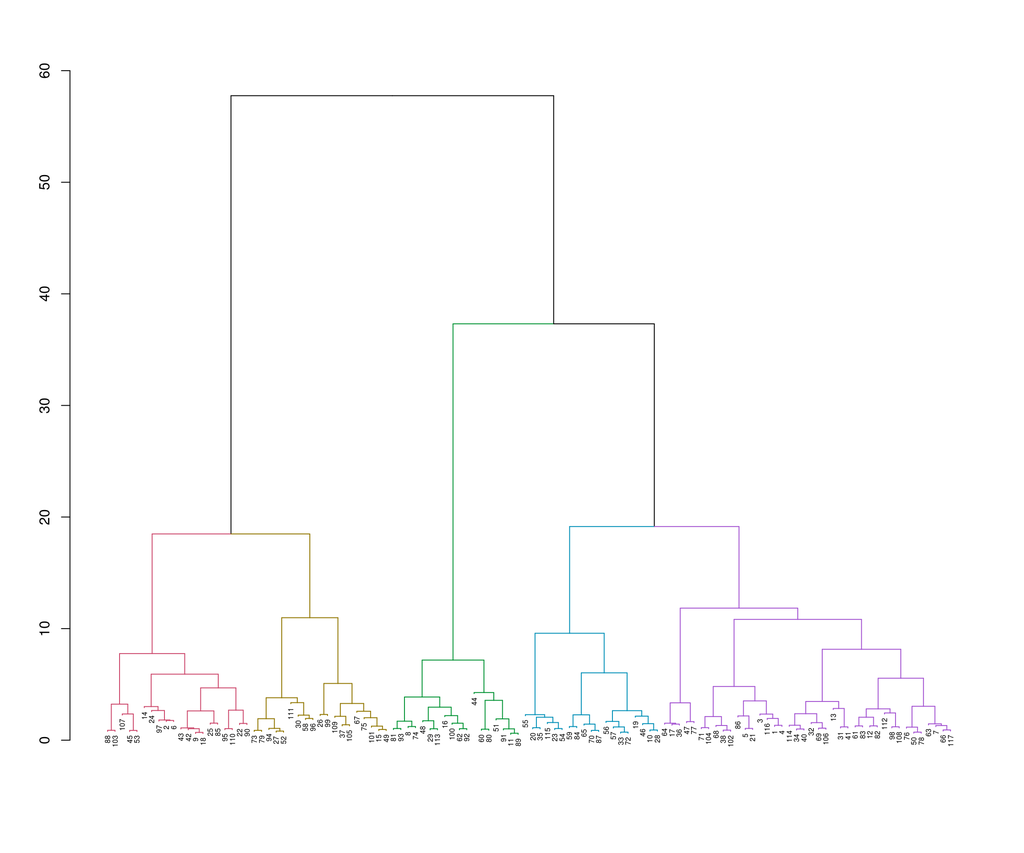

plot clusters

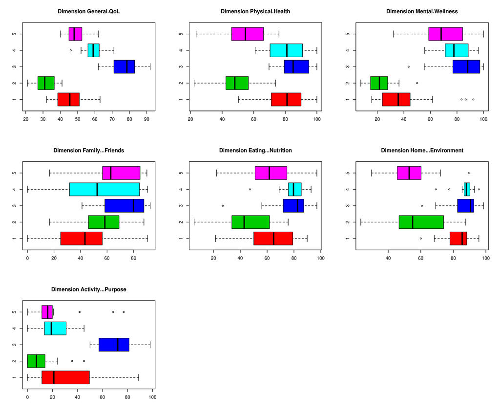

## 4.2 K-means

k-means clustering aims to partition $n$ observations into $k$ clusters in which each observation belongs to the cluster with the nearest mean, serving as a prototype of the cluster.

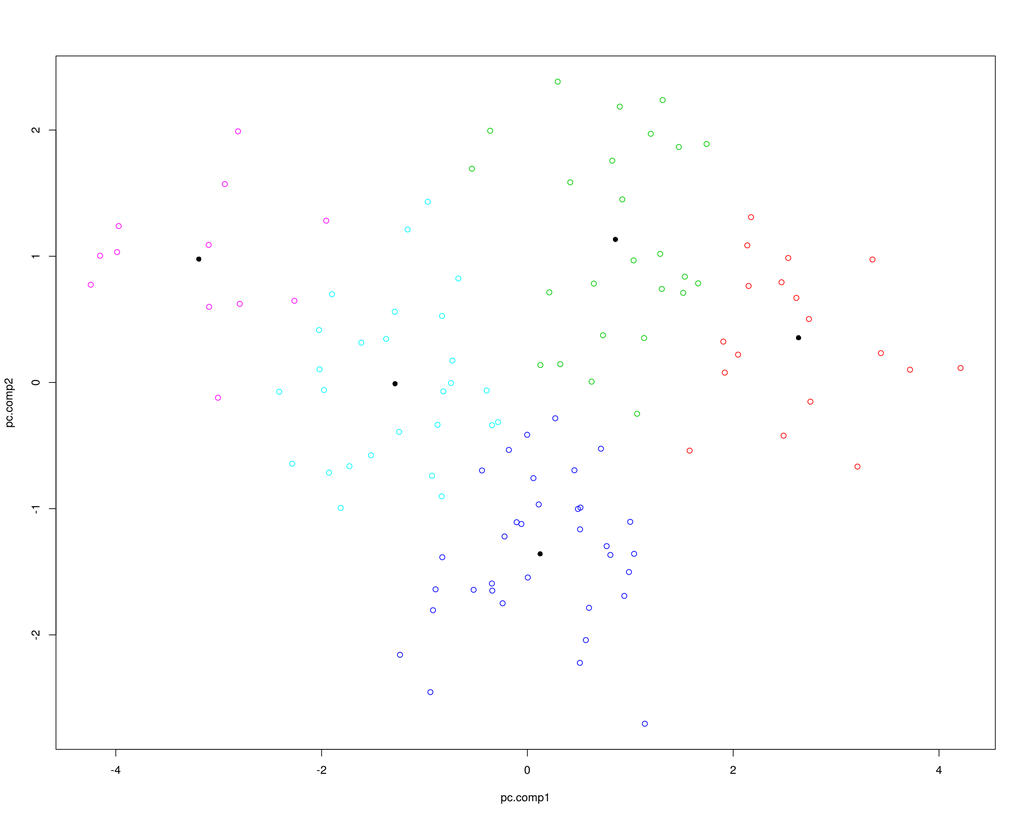

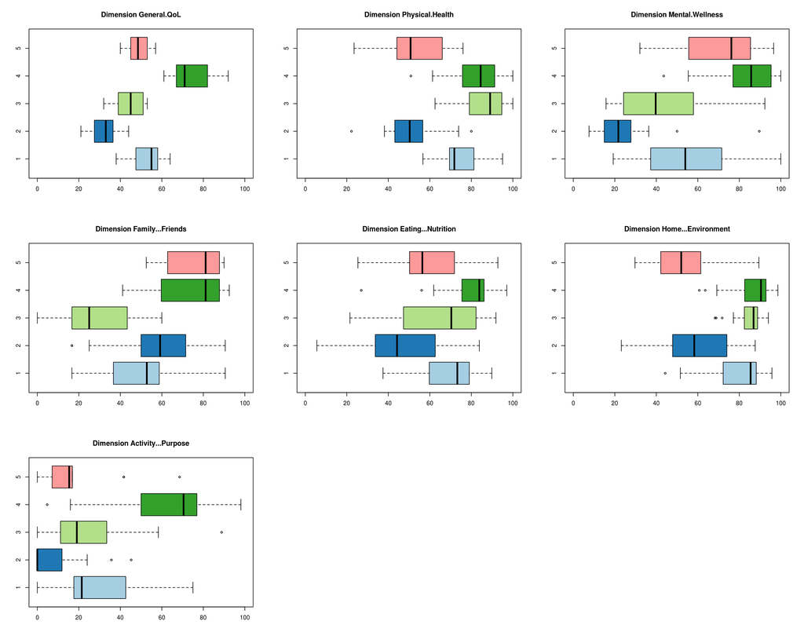